# **Exploring Ecommerce dataset using Google BigQuery**

**Task 1. Star the lab project in BigQuery**

In this section you add the data-to-insights project to your environment resources.

1. Click Navigation menu > BigQuery
2. The Welcome to BigQuery in the Cloud Console message box opens.

Note: The Welcome to BigQuery in the Cloud Console message box provides a link to the quickstart guide and UI updates.

3. Click Done.
4. BigQuery public datasets are not displayed by default in the BigQuery web UI so you'll open the public datasets project.
5. Click + Add Data.
6. Select Star a project by name.
7. For Project name, enter data-to-insights.
8. Click Star.
9. In the explorer pane, you will see the data-to-insights project starred.

```python
from google.colab import files
from IPython.display import Image
```

```python
uploaded = files.upload()
```

Upload widget is only available when the cell has been executed in the current browser session. Please rerun this cell to enable.

```
Saving Lab1_img1.png to Lab1_img1.png
```

[figure not shown]

```python
Image('Lab1_img1.png', width = 800)
```

```python
uploaded = files.upload()
```

Upload widget is only available when the cell has been executed in the current browser session. Please rerun this cell to enable.

```
Saving Lab1_img2.png to Lab1_img2.png
```

[figure not shown]

```python
Image('Lab1_img2.png', width = 800)
```

```python
uploaded = files.upload()
```

Upload widget is only available when the cell has been executed in the current browser session. Please rerun this cell to enable.

```
Saving Lab1_img3.png to Lab1_img3.png
```

[figure not shown]

```python
Image('Lab1_img3.png', width = 800)
```

```python
uploaded = files.upload()
```

Upload widget is only available when the cell has been executed in the current browser session. Please rerun this cell to enable.

```
Saving Lab1_img4.png to Lab1_img4.png
```

[figure not shown]

```python
Image('Lab1_img4.png', width = 500)
```

```python
uploaded = files.upload()
```

Upload widget is only available when the cell has been executed in the current browser session. Please rerun this cell to enable.

```
Saving Lab1_img5.png to Lab1_img5.png
```

[figure not shown]

```python
Image('Lab1_img5.png', width = 600)
```

**Task 2. Explore Ecommerce data and identify duplicate records**

Scenario: Your data analyst team exported the Google Analytics logs for an ecommerce website into BigQuery and created a new table of all the raw ecommerce visitor session data.

1. Explore the all_sessions_raw table data:
2. Expand data-to-insights project.
3. Expand ecommerce.
4. Click all_sessions_raw.
5. In the right pane, a section opens that provides 3 views of the table data:

Schema tab: Field name, Type, Mode, and Description; the logical constraints used to organize the data.

Details tab: Table metadata

Preview tab: Table preview

Click the Details tab to view the table metadata.

```python
uploaded = files.upload()
```

Upload widget is only available when the cell has been executed in the current browser session. Please rerun this cell to enable.

```
Saving Lab1_img6.png to Lab1_img6.png
```

[figure not shown]

```python
Image('Lab1_img6.png', width = 500)
```

```python
uploaded = files.upload()
```

Upload widget is only available when the cell has been executed in the current browser session. Please rerun this cell to enable.

```
Saving Lab1_img7.png to Lab1_img7.png
```

[figure not shown]

```python
Image('Lab1_img7.png', width = 500)
```

```python
uploaded = files.upload()
```

Upload widget is only available when the cell has been executed in the current browser session. Please rerun this cell to enable.

```
Saving Lab1_img8.png to Lab1_img8.png
```

[figure not shown]

```python
Image('Lab1_img8.png', width = 500)
```

```python
uploaded = files.upload()
```

Upload widget is only available when the cell has been executed in the current browser session. Please rerun this cell to enable.

```
Saving Lab1_img9.png to Lab1_img9.png
```

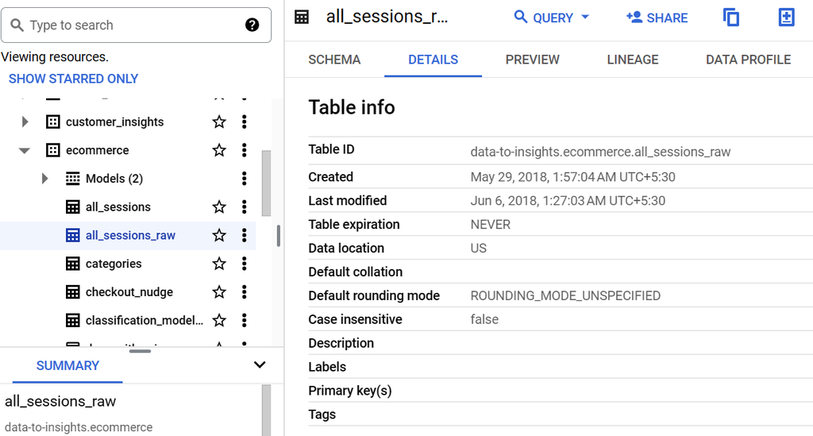

```python
Image('Lab1_img9.png', width = 500)
```

```python
uploaded = files.upload()
```

Upload widget is only available when the cell has been executed in the current browser session. Please rerun this cell to enable.

```
Saving Lab1_img10.png to Lab1_img10.png
```

[figure not shown]

```python
Image('Lab1_img10.png', width = 500)
```

**Task 3: Identify duplicate rows**

Seeing a sample amount of data may give you greater intuition for what is included in the dataset. To preview sample rows from the table without using SQL, click the Preview tab.

1. Scan and scroll through the rows. There is no singular field that uniquely identifies a row, so you need advanced logic to identify duplicate rows.
2. Your query uses the SQL GROUP BY function on every field and counts (COUNT) where there are rows that have the same values across every field.
3. **If every field is unique, the COUNT will return 1** as there are no other groupings of rows with the exact same value for all fields.
4. **If there is a row with the same values for all fields, they will be grouped together and the COUNT will be greater than 1**. The last part of the query is an aggregation filter using HAVING to only show the results that have a COUNT of duplicates greater than 1.

```python
uploaded = files.upload()
```

Upload widget is only available when the cell has been executed in the current browser session. Please rerun this cell to enable.

```
Saving Lab1_img11.png to Lab1_img11.png
```

[figure not shown]

```python
Image('Lab1_img11.png', width = 800)
```

```python
uploaded = files.upload()
```

Upload widget is only available when the cell has been executed in the current browser session. Please rerun this cell to enable.

```
Saving Lab1_img12.png to Lab1_img12.png
```

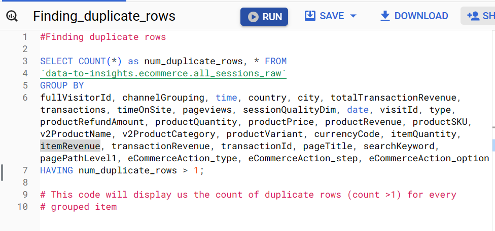

```python
Image('Lab1_img12.png', width = 800)
```

```python
uploaded = files.upload()
```

Upload widget is only available when the cell has been executed in the current browser session. Please rerun this cell to enable.

```
Saving Lab1_img13.png to Lab1_img13.png
```

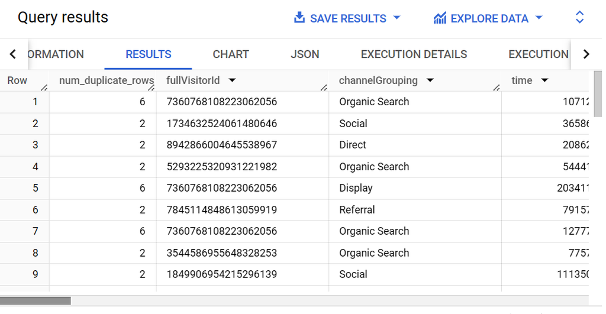

```python
Image('Lab1_img13.png', width = 800)
```

**Task 4: Identify duplicate values in 'all_sessions_table'**

Analyze the new all_sessions table In this section you use a deduplicated table called all_sessions.

Scenario: Your data analyst team has provided you with this query, and your schema experts have identified the key fields that must be unique for each record per your schema.

Run the query to confirm that no duplicates exist, this time in the all_sessions table:

```python
uploaded = files.upload()
```

Upload widget is only available when the cell has been executed in the current browser session. Please rerun this cell to enable.

```
Saving Lab1_img14.png to Lab1_img14.png
```

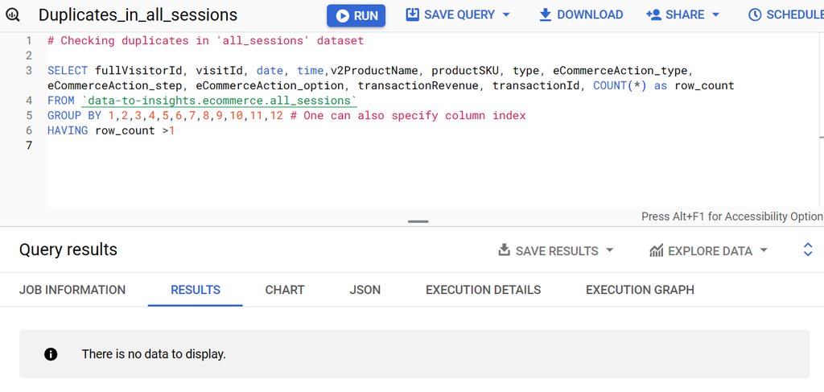

```python
Image('Lab1_img14.png', width = 800)
```

As per the result, there are no duplicate values in the dataset.

**Task 5. Write a query that shows total unique visitors for all_sessions table**

In this section, you query for insights on the ecommerce dataset.

Write a query that shows total unique visitors Your query determines the total views by counting product_views and the number of unique visitors by counting fullVisitorID.

```python
uploaded = files.upload()
```

Upload widget is only available when the cell has been executed in the current browser session. Please rerun this cell to enable.

```
Saving Lab1_img15.png to Lab1_img15.png
```

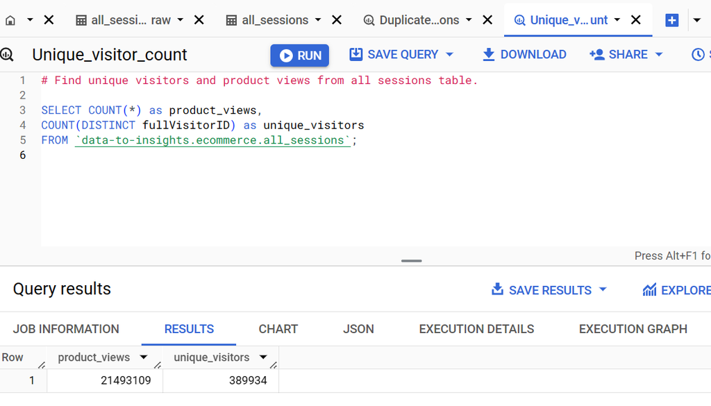

```python
Image('Lab1_img15.png', width = 800)
```

**Task 6: Write a query that shows total unique visitors(fullVisitorID) by the referring site (channelGrouping)**

```python
uploaded = files.upload()
```

Upload widget is only available when the cell has been executed in the current browser session. Please rerun this cell to enable.

```
Saving Lab1_img16.png to Lab1_img16.png
```

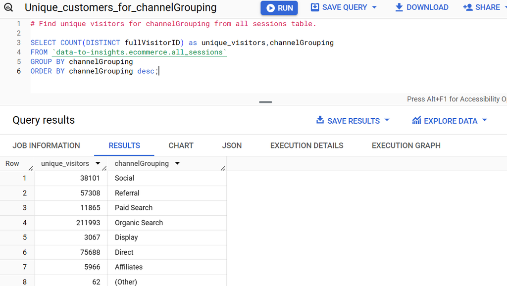

```python
Image('Lab1_img16.png', width = 800)
```

**Task 7: Find top 5 Product details for type 'Page' from all_sessions table**

In Google Analytics, a visitor can "view" a product during the following interaction types: 'page', 'screenview', 'event', 'transaction', 'item', 'social', 'exception', 'timing'. For our purposes, simply filter for only type = 'PAGE'.

Here in product details one can consider v2productName as Prodtct name and count od all columns as product views.

```python
uploaded = files.upload()
```

Upload widget is only available when the cell has been executed in the current browser session. Please rerun this cell to enable.

```
Saving Lab1_img17.png to Lab1_img17.png
```

[figure not shown]

```python
Image('Lab1_img17.png', width = 800)
```

**Task 8: Modify the same query using 'with clause'. Define unique products viewed by customer first**

Refine the query to no longer double-count product views for visitors who have viewed a product many times. Each distinct product view should only count once per visitor.

```python
uploaded = files.upload()
```

Upload widget is only available when the cell has been executed in the current browser session. Please rerun this cell to enable.

```
Saving Lab1_img18.png to Lab1_img18.png
```

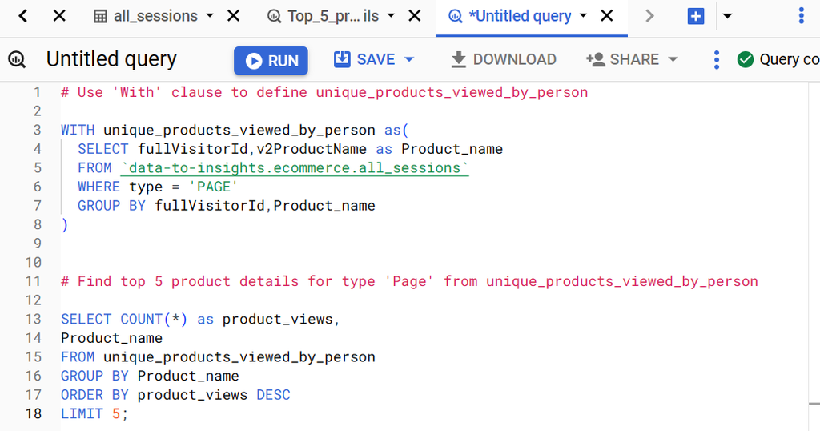

```python
Image('Lab1_img18.png', width = 800)
```

```python
uploaded = files.upload()
```

Upload widget is only available when the cell has been executed in the current browser session. Please rerun this cell to enable.

```
Saving Lab1_img19.png to Lab1_img19.png
```

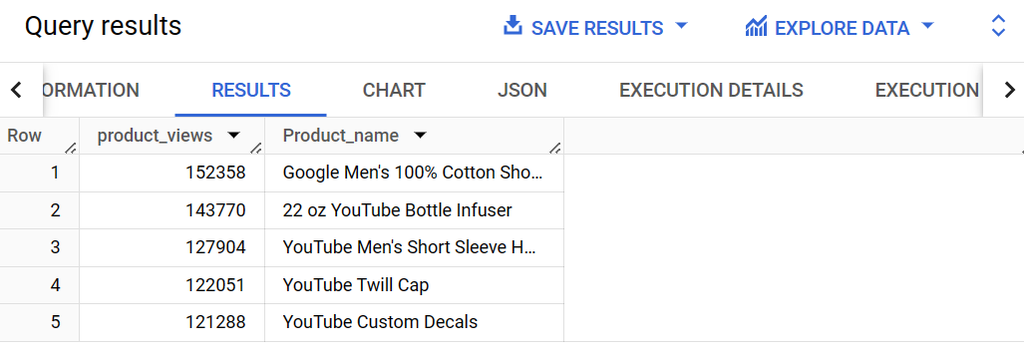

```python
Image('Lab1_img19.png', width = 800)
```

**Task 9: Modify the above query to find total number of distinct products ordered (i.e. count productQuantity) and the total number (sum productQuantity) of total units ordered.**

```python
uploaded = files.upload()
```

Upload widget is only available when the cell has been executed in the current browser session. Please rerun this cell to enable.

```
Saving Lab1_img20.png to Lab1_img20.png
```

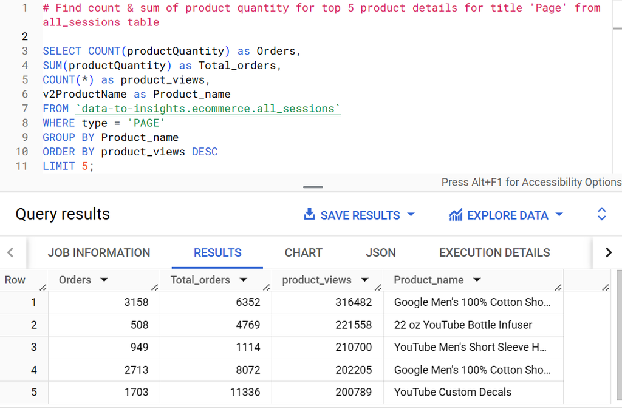

```python
Image('Lab1_img20.png', width = 800)
```

**Task 10: Modify the above query to find Averagae per orders as well along with total number of distinct products ordered (i.e. count productQuantity) and the total number (sum productQuantity) of total units ordered.**

Here Avg_per_orders = (Sum productQuantity/Count productQuantity)

```python
uploaded = files.upload()
```

Upload widget is only available when the cell has been executed in the current browser session. Please rerun this cell to enable.

```
Saving Lab1_img21.png to Lab1_img21.png
```

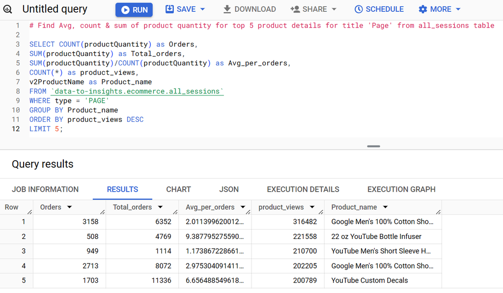

```python
Image('Lab1_img21.png', width = 800)
```

**Task 11: Calculate a conversion rate**

Write a conversion rate query for products with these qualities:

More than 1000 units were added to a cart or ordered AND are not frisbees

```python
uploaded = files.upload()
```

Upload widget is only available when the cell has been executed in the current browser session. Please rerun this cell to enable.

```
Saving Lab1_img22.png to Lab1_img22.png
```

[figure not shown]

```python
Image('Lab1_img22.png', width= 800)
```

```python
uploaded = files.upload()
```

Upload widget is only available when the cell has been executed in the current browser session. Please rerun this cell to enable.

```
Saving Lab1_img23.png to Lab1_img23.png
```

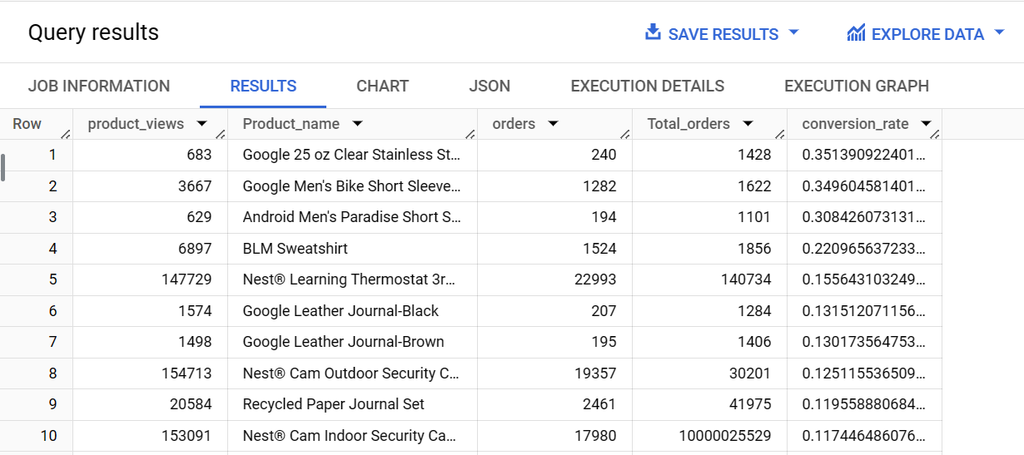

```python
Image('Lab1_img23.png', width = 800)
```

**Task 12: Track visitor checkout progress**

Write a query that shows the eCommerceAction_type and the distinct count of fullVisitorId associated with each type.

```python
uploaded = files.upload()
```

Upload widget is only available when the cell has been executed in the current browser session. Please rerun this cell to enable.

```
Saving Lab1_img24.png to Lab1_img24.png
```

[figure not shown]

```python
Image('Lab1_img24.png', width = 800)
```

**Task 13: Use a Case Statement to add a new column to your previous query to display the eCommerceAction_type label (such as “Completed purchase”)**

You are given this mapping for the action type:

Unknown = 0

Add product(s) to cart = 3

Remove product(s) from cart = 4

Check out = 5

Completed purchase = 6

Refund of purchase = 7

Checkout options = 8

```python
uploaded = files.upload()
```

Upload widget is only available when the cell has been executed in the current browser session. Please rerun this cell to enable.

```
Saving Lab1_img25.png to Lab1_img25.png
```

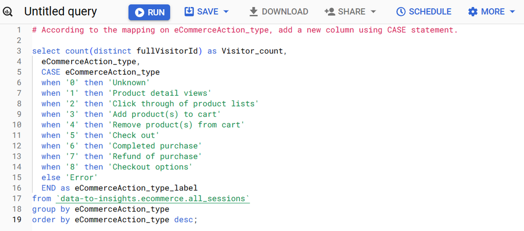

```python
Image('Lab1_img25.png', width = 800)
```

```python
uploaded = files.upload()
```

Upload widget is only available when the cell has been executed in the current browser session. Please rerun this cell to enable.

```
Saving Lab1_img26.png to Lab1_img26.png
```

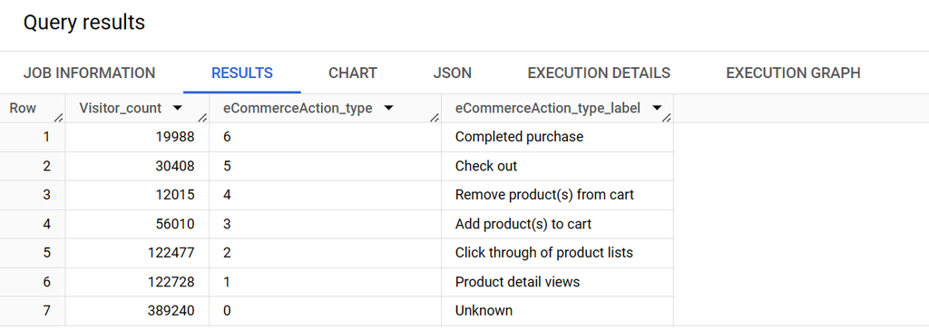

```python
Image('Lab1_img26.png', width = 800)
```

**Task 14: Track abandoned carts from high quality sessions**

Write a query using aggregation functions that returns the unique session IDs of those visitors who have added a product to their cart but never completed checkout (abandoned their shopping cart).

```python
uploaded = files.upload()
```

Upload widget is only available when the cell has been executed in the current browser session. Please rerun this cell to enable.

```
Saving Lab1_img27.png to Lab1_img27.png
```

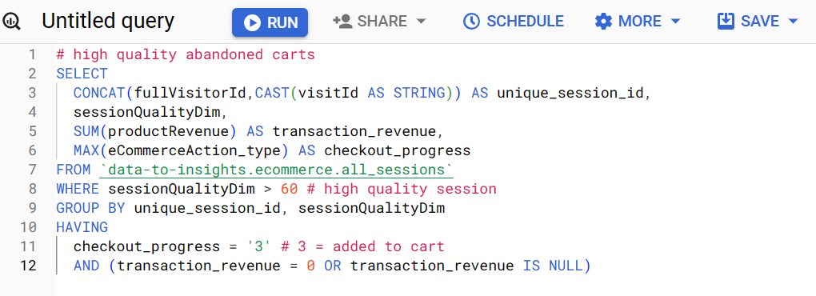

```python
Image('Lab1_img27.png', width = 800)
```

```python
uploaded = files.upload()
```

Upload widget is only available when the cell has been executed in the current browser session. Please rerun this cell to enable.

```
Saving Lab1_img28.png to Lab1_img28.png
```

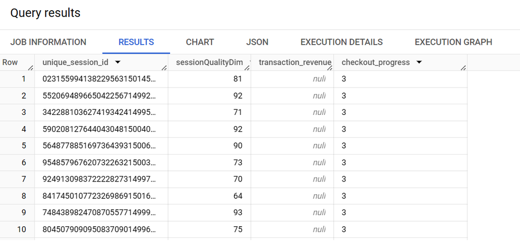

```python
Image('Lab1_img28.png', width = 800)
```